# Monster Energy

A Journey Across Auckland

For this observational survey, passion has led me to critically ask the question “where can I get the best value for my crippling energy drink addiction?” and the answer may surprise you.

There are many factors to consider when deciding where to go to get your beloved $Monster \ Energy^{TM}$ blend, where considerations don’t purely hinge upon price.

Thus, within our analysis, it is first critical to ask;

## *Where can I find Monster Energy?*

Well lets consider locations that you know typically sell energy drinks.

Chances are, there exists a dairy that sells a large variety of $Monster \ Energy^{TM}$, while another dairy won’t sell $Monster \ Energy^{TM}$ at all.

Here’s a break down of proportional observations that the location sells $Monster \ Energy^{TM}$, should a location sell Energy Drinks.

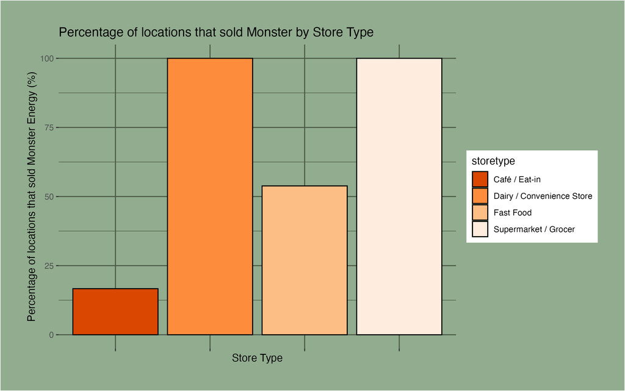

A Column Graph | All sampled Supermarkets and Dairies had Monster Energy

The above plot shows us that all supermarkets and dairies sampled in our survey that happened to sell energy drinks also sold $Monster \ Energy^{TM}$.

This is great news! But what are some of the drawbacks of these locations outside of price?

One key consideration on whether or not a location is satisfactory is the range of flavours they have available.

Thus our next question is;

## *How many different flavours can you typically find at each location?*

And on top of that, we also want to easily compare the differences.

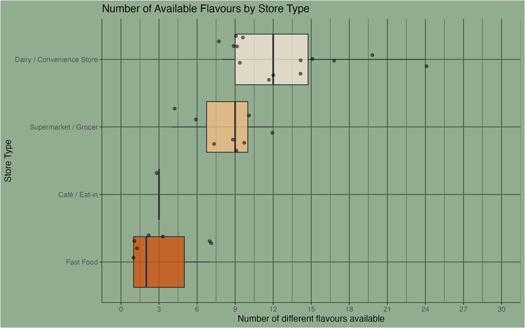

A Box Plot | Dairy by far has the most available options

The above box plot shows some very interesting stuff! Supermarkets and dairies both happen to have the largest average range between all observed categories.

Furthermore, while it’s clear that the average number of options available at a dairy is well above the interquartile range of a supermarket, their interquartile ranges do in fact overlap slightly. Thus leading me to conclude that both are fairly adequate locations to find $Monster \ Energy^{TM}$.

## *What about price?*

Now while I was exploring my data, I found the price disparity between categories to be fairly close to each other and not really informative. Thus when considering what good value is, a general approach was used.

The below graph consists of price density across the sampled Auckland region.

This graph ideally should give a comparative basis on what a good price is considered good value.

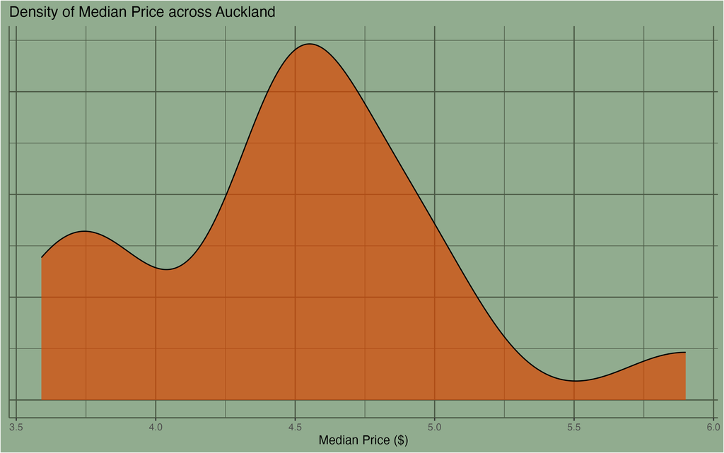

Density Graph | Majoty of prices lie below $4.6

Given the desity plot, we can observe a large proportion of drinks at a $4.6 ish price point. Thus it would probably be poor value if you purchase above this point.

## *Sampling method considerations.*

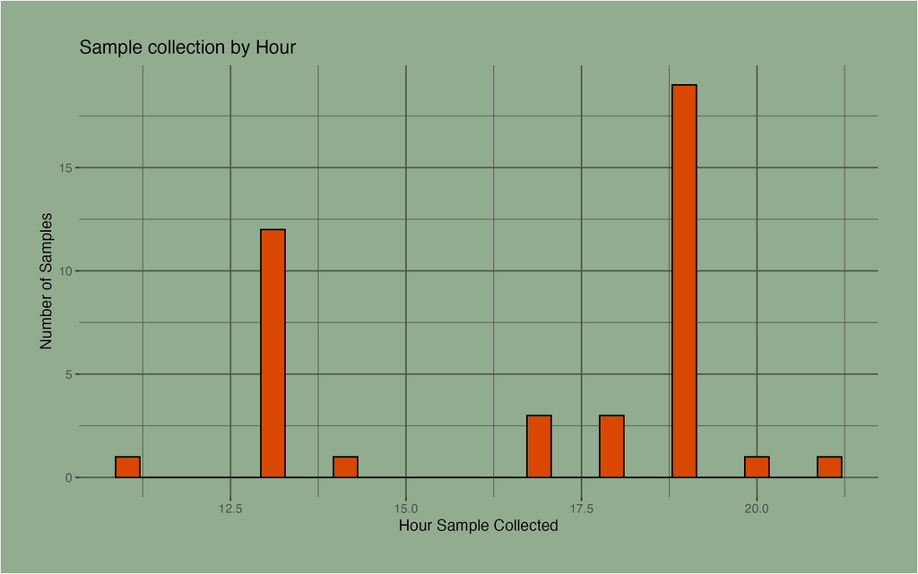

Histogram | Most observations made at 1pm and 7pm

The above histogram represents the number of samples added to the survey given the time of day. An important factor to consider is that the majority of the samples were taken in the evening.

This has manifested because of a sampling method used, that being, consulting location websites for their catalog. This could introduce a potential bias where the online catalog does not include an accurate description of what’s available at the specific location.